# COURSERA-REPORODUCIBLE RESEARCH PA-1

## Loading and preprocessing the data

**1.Loading the data**

The file containing the activity monitoring data is downloaded and stored in current working directory. It is read in R using read.csv function.

```r
activity_data<-read.csv(".\\activity.csv")
```

**2.Pre-procesing the data**

```r
str(activity_data)
```

```
## 'data.frame':    17568 obs. of  3 variables:
##  $ steps   : int  NA NA NA NA NA NA NA NA NA NA ...
##  $ date    : Factor w/ 61 levels "2012-10-01","2012-10-02",..: 1 1 1 1 1 1 1 1 1 1 ...
##  $ interval: int  0 5 10 15 20 25 30 35 40 45 ...
```

It can be seen that class of *date* column is factor.It is changed to date class using **as.Date** function.

```r
activity_data$date<-as.Date(activity_data$date)
```

## What is mean total number of steps taken per day?

**1.Total number of steps taken per day**

Total number of steps taken per day is calculated as

```r
library(dplyr,warn.conflicts = FALSE)
steps_by_day<-activity_data %>% group_by(date) %>% summarise(Total_steps=sum(steps,na.rm = TRUE))
head(steps_by_day)
```

```
## Source: local data frame [6 x 2]
##
##         date Total_steps
## 1 2012-10-01           0
## 2 2012-10-02         126
## 3 2012-10-03       11352
## 4 2012-10-04       12116
## 5 2012-10-05       13294
## 6 2012-10-06       15420
```

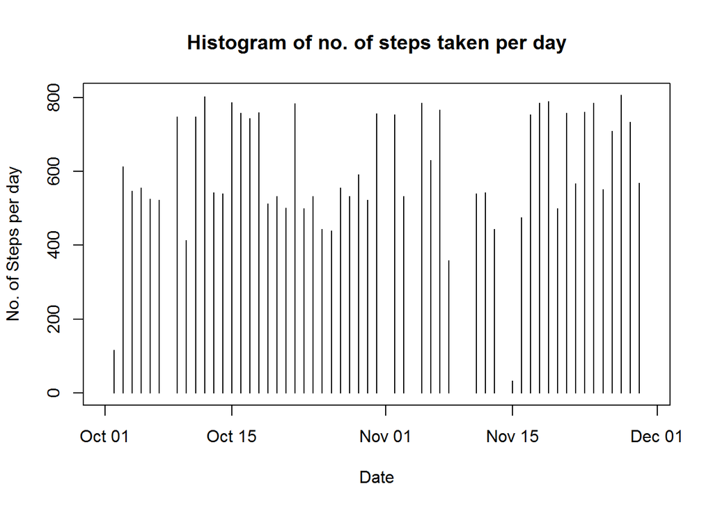

```r
plot(activity_data$date,activity_data$steps,xlab="Date",ylab="No. of Steps per day",main="Histogram of no. of steps taken per day",type="h")
```

Mean and Median of number of steps taken per day is found using *mean* and *median* function.

```r
mean_step<-mean(activity_data$steps,na.rm = TRUE)
median_step<-median(activity_data$steps,na.rm = TRUE)
```

## Average daily activity pattern

**1.Time-seies plot**

Average number of steps taken per 5-minute interval can be found using dplyr and stoerd in *interval_avg* dataframe.

```r
interval_avg<-activity_data %>% group_by(interval) %>% summarise(mean_steps=mean(steps,na.rm=TRUE))
```

The time-series plot of average number of steps taken per 5-minute interval is shown below

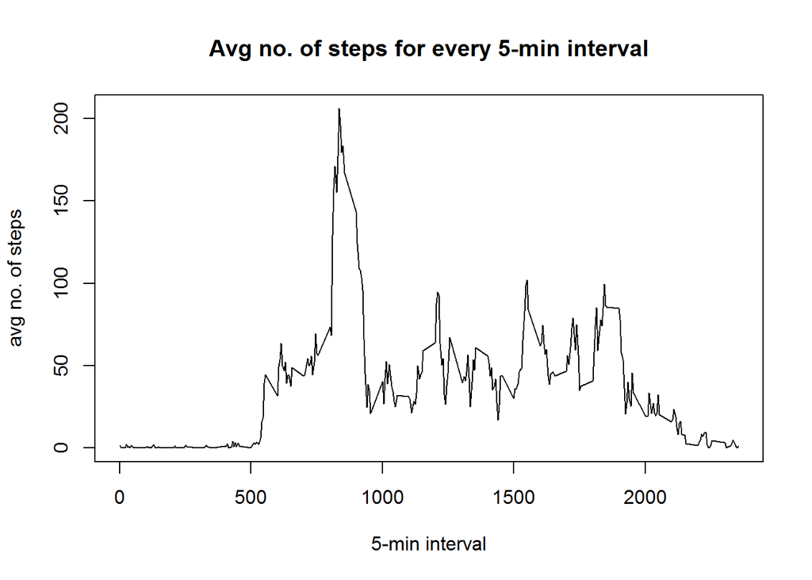

```r
plot(interval_avg$interval,interval_avg$mean_steps,type="l",xlab="5-min interval",ylab="avg no. of steps",main="Avg no. of steps for every 5-min interval")
```

**2.calculating 5-minute interval with maximum number of steps**

Data Frame *interval_avg* contains the average number of steps taken for every 5-minute period.From that time period containing the maximum value for average number of steps can be found as

```r
max_steps_time_period<-interval_avg[which.max(interval_avg$mean_steps),1]
```

It can be found that **time period 835** contains the maximum value for average number of steps.

## Dealing with missing values

**1.calculating the total number of missing values**

Total number of missing values in the given data is calculated as below.

```r
NA_count<-length(activity_data[is.na(activity_data$steps),1])
```

It is found that 2304 rows are having NA in steps column.

**2.Devising a strategy and creating new Dataset**

It has been found that data is missing for all the 5-minute intervals in some of the days(example:2012-10-01).

```r
activity_data[activity_data$date=="2012-10-01",1]
```

```
##   [1] NA NA NA NA NA NA NA NA NA NA NA NA NA NA NA NA NA NA NA NA NA NA NA
##  [24] NA NA NA NA NA NA NA NA NA NA NA NA NA NA NA NA NA NA NA NA NA NA NA
##  [47] NA NA NA NA NA NA NA NA NA NA NA NA NA NA NA NA NA NA NA NA NA NA NA
##  [70] NA NA NA NA NA NA NA NA NA NA NA NA NA NA NA NA NA NA NA NA NA NA NA
##  [93] NA NA NA NA NA NA NA NA NA NA NA NA NA NA NA NA NA NA NA NA NA NA NA
## [116] NA NA NA NA NA NA NA NA NA NA NA NA NA NA NA NA NA NA NA NA NA NA NA
## [139] NA NA NA NA NA NA NA NA NA NA NA NA NA NA NA NA NA NA NA NA NA NA NA
## [162] NA NA NA NA NA NA NA NA NA NA NA NA NA NA NA NA NA NA NA NA NA NA NA
## [185] NA NA NA NA NA NA NA NA NA NA NA NA NA NA NA NA NA NA NA NA NA NA NA
## [208] NA NA NA NA NA NA NA NA NA NA NA NA NA NA NA NA NA NA NA NA NA NA NA
## [231] NA NA NA NA NA NA NA NA NA NA NA NA NA NA NA NA NA NA NA NA NA NA NA
## [254] NA NA NA NA NA NA NA NA NA NA NA NA NA NA NA NA NA NA NA NA NA NA NA
## [277] NA NA NA NA NA NA NA NA NA NA NA NA
```

Hence mean value of one day cannot be used to replace tha NA values.

Hence it is proposed to use mean of all 5-minute interval to replace the NA values.Here dataframe *interval_avg* already created can be used.It contains the mean of steps taken for all the 5-minute interval perids.

```r
head(interval_avg)
```

```
## Source: local data frame [6 x 2]
##
##   interval mean_steps
## 1        0  1.7169811
## 2        5  0.3396226
## 3       10  0.1320755
## 4       15  0.1509434
## 5       20  0.0754717
## 6       25  2.0943396
```

Since *mean_steps* column is in dotted decimal notation,it is rounded off to nearest integer.

```r
interval_avg$mean_steps<-round(interval_avg$mean_steps)
head(interval_avg)
```

```
## Source: local data frame [6 x 2]
##
##   interval mean_steps
## 1        0          2
## 2        5          0
## 3       10          0
## 4       15          0
## 5       20          0
## 6       25          2
```

New dataset is created by replacing all NA values in *activity_data* with mean steps values in *interval_avg*

```r
NA_interval<-activity_data[is.na(activity_data$steps),3]
index<-match(NA_interval,interval_avg$interval)
replacing_values<-interval_avg[index,2]
new_activity_data<-activity_data
new_activity_data[is.na(new_activity_data$steps),1]<-replacing_values
head(new_activity_data,10)
```

```
##    steps       date interval
## 1      2 2012-10-01        0
## 2      0 2012-10-01        5
## 3      0 2012-10-01       10
## 4      0 2012-10-01       15
## 5      0 2012-10-01       20
## 6      2 2012-10-01       25
## 7      1 2012-10-01       30
## 8      1 2012-10-01       35
## 9      0 2012-10-01       40
## 10     1 2012-10-01       45
```

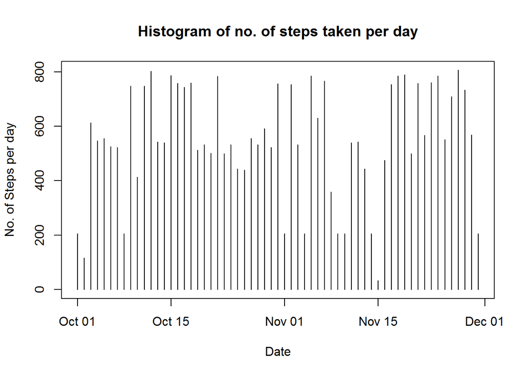

```r
plot(new_activity_data$date,new_activity_data$steps,xlab="Date",ylab="No. of Steps per day",main="Histogram of no. of steps taken per day",type="h")
```

Mean and Median of steps are calculated from the new data set.

```r
new_mean<-mean(new_activity_data$steps)
new_median<-median(new_activity_data$steps)
```

## Differences in activity patterns between weekdays and weekend

**1.creating new factor variable to differntiate weekday and weekend**

Using *weekdays* function,day of the week can be found from the date.A new column containing day of the week is added to original dataframe.

```r
activity_data$weekday<-weekdays(activity_data$date)
```

**2.Creating plot seperately for weekdays and weekends**

This weekday column is used for filtering(with *dplyr*) the weekdays and weekend days seperately and average number of steps taken are calculated seperately.

```r
weekend_avg<-filter(activity_data,grepl('Saturday|Sunday',weekday)) %>% group_by(interval) %>% summarise(mean_steps=mean(steps,na.rm=TRUE))
weekdays_avg<-filter(activity_data,!grepl('Saturday|Sunday',weekday)) %>% group_by(interval) %>% summarise(mean_steps=mean(steps,na.rm=TRUE))
```

Plots for average number of steps taken for each 5-min interval is made seperately for weekdays and weekend days.

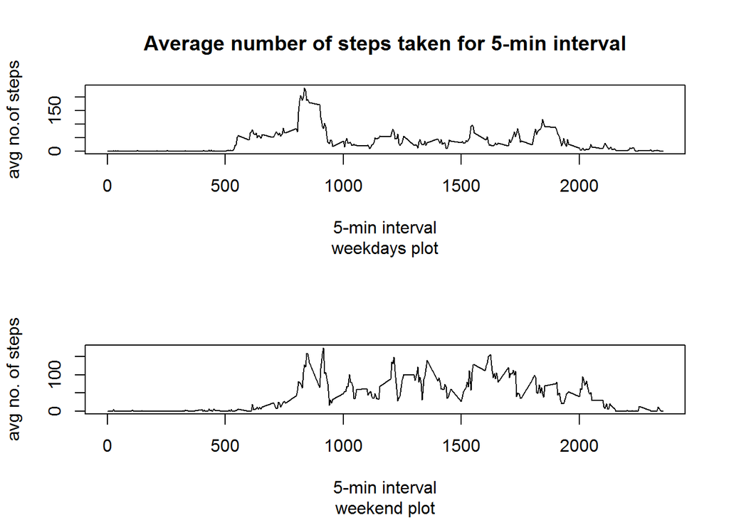

```r
par(mfrow=c(2,1))
plot(weekdays_avg$interval,weekdays_avg$mean_steps,type="l",xlab="5-min interval",ylab="avg no.of steps",sub="weekdays plot",main="Average number of steps taken for 5-min interval")
plot(weekend_avg$interval,weekend_avg$mean_steps,type="l",xlab="5-min interval",ylab="avg no. of steps",sub="weekend plot")
```